# Project 5

### EAE 127 Edgardo Rivera Godoy 912753270

## Introduction

Project 5 compares the boundary layers of laminar flow and turbulent flow. It then introduced the idea of a Viscous/Inviscid Interaction tool (VIvI). The code for this VIvI tool was given. It just needed to be adapted in order to perform 3 iterations. The purpose of performing 3 iterations is to see the convergence of the the resulting surface and camber of the airfoil due to viscous effects.

## Imports and Plotting Setup

```python
### STANDARD IMPORTS #################################################
import numpy as np
import pandas as pd
import matplotlib.pyplot as plt

### JUPYTER NOTEBOOK SETTINGS ########################################
#Plot all figures in full-size cells, no scroll bars
%matplotlib inline
#Disable Python Warning Output
#(NOTE: Only for production, comment out for debugging)
import warnings
warnings.filterwarnings('ignore')

### PLOTTING DEFAULTS BOILERPLATE (OPTIONAL) #########################
#SET DEFAULT FIGURE APPERANCE
import seaborn as sns #Fancy plotting package
#No Background fill, legend font scale, frame on legend
sns.set(style='whitegrid', font_scale=1.5, rc={'legend.frameon': True})
#Mark ticks with border on all four sides (overrides 'whitegrid')
sns.set_style('ticks')
#ticks point in
sns.set_style({"xtick.direction": "in","ytick.direction": "in"})
#fix invisible marker bug
sns.set_context(rc={'lines.markeredgewidth': 0.1})
#restore default matplotlib colormap
mplcolors = ['#1f77b4', '#ff7f0e', '#2ca02c', '#d62728', '#9467bd',
             '#8c564b', '#e377c2', '#7f7f7f', '#bcbd22', '#17becf']
sns.set_palette(mplcolors)
#Get color cycle for manual colors
colors = sns.color_palette()
#SET MATPLOTLIB DEFAULTS
    #(call after seaborn, which changes some defaults)
params = {
        #FONT SIZES
        'axes.labelsize' : 30, #Axis Labels
        'axes.titlesize' : 30, #Title
        'font.size'      : 28, #Textbox
        'xtick.labelsize': 22, #Axis tick labels
        'ytick.labelsize': 22, #Axis tick labels
        'legend.fontsize': 24, #Legend font size
        'font.family'    : 'serif',
        'font.fantasy'   : 'xkcd',
        'font.sans-serif': 'Helvetica',
        'font.monospace' : 'Courier',
        #AXIS PROPERTIES
        'axes.titlepad'  : 2*6.0, #title spacing from axis
        'axes.grid'      : True,  #grid on plot
        'figure.figsize' : (8,8),   #square plots
        'savefig.bbox'   : 'tight', #reduce whitespace in saved figures
        #LEGEND PROPERTIES
        'legend.framealpha'     : 0.5,
        'legend.fancybox'       : True,
        'legend.frameon'        : True,
        'legend.numpoints'      : 1,
        'legend.scatterpoints'  : 1,
        'legend.borderpad'      : 0.1,
        'legend.borderaxespad'  : 0.1,
        'legend.handletextpad'  : 0.2,
        'legend.handlelength'   : 1.0,
        'legend.labelspacing'   : 0,
}
import matplotlib
matplotlib.rcParams.update(params) #update matplotlib defaults, call after seaborn
### END OF BOILERPLATE ##################################################

import mses
import pyxfoil
```

## Problem 1

### Methods

For Problem 1, the reynolds number for each of the two cases was calculated and used to estimate the Boundary Layer Velocity Distribution. This was done by obtaining the estimates of the non-dimensional streamwise velocity $(\frac{u}{u_e})$, for both the laminar and turbulent cases for an array of $\frac{y}{\delta}$ between 0 and 1. These non-dimensional values were then dimensionalized by using the given velocites and the laminar and turbulent Blasius solution approximations for boundary layer thickness of a flat plate.

### Equations

Reynold's Number: $$Re = \frac{\rho V_\infty L}{\mu}$$

Non-dimensional velocity as a function of non-dimensional height: $$\frac{u}{u_e}\bigg|_{lam} \approx \bigg(\frac{2y}{\delta} -\frac{y^2}{\delta^2} \bigg);\qquad \frac{u}{u_e}\bigg|_{turb} \approx \bigg(\frac{y}{\delta} \bigg)^\frac{1}{7} $$

Laminar and turbulent Blasius solution approximations for boundary layer thickness of a flat plate: $$\delta(x)_{lam} = \frac{5.0}{\sqrt{Re_x}}; \qquad \delta(x)_{turb} = \frac{0.16}{Re_x^\frac{1}{7}} $$

Skin Friction Drag: $$C_{f,lam} = \frac{1.328}{\sqrt{Re_c}}; \qquad C_{f,turb} = \frac{0.074}{Re_c^\frac{1}{5}} $$

### Code and Results

Below, the Reynold's Number for both cases are obtained.

```python
L = 6/12
mu = 3.737e-7 #lb s/ft2
rho1 = 2.3769e-3 #slugs / ft^3
v1 = 20.2537 #ft/s
rho2 = 8.9068e-4 #slugs / ft^3
v2 = 928.295 #ft/s

Re1 = rho1*v1*L/mu
Re2 = rho2*v2*L/mu

a1 = 1116
a2 = 996
M1 = v1/a1
M2 = v2/a2

print('The reyonolds number of the antenna at taxi is {:.2f}, and the Mach Number is {:.3f}'.format(Re1,M1))
print('The reyonolds number of the antenna at cruise is {:.2f}, and the Mach Number is {:.3f}'.format(Re2,M2))
```

```
The reyonolds number of the antenna at taxi is 64411.32, and the Mach Number is 0.018
The reyonolds number of the antenna at cruise is 1106253.40, and the Mach Number is 0.932
```

From these results we can see that for the taxi case, the Re is fairly low, well under the $Re_{cr}$. However, for the cruise case, it is much higher, making it turbulent BL flow. Since the Ma for the taxi case is well below 0.3, it can be said that it is an incompressible flow and that this assumption is valid. For the cruise case, however, it is well above 0.3 at nearly Mach 1. This means that incompressible flow does not hold true for the cruise case.

Below the non-dimensional veloity is calculated and plotted with respect to the non-dimensional height.

```
<function matplotlib.pyplot.show(*args, **kw)>
```

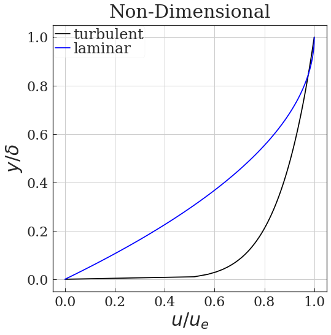

```python
y_delt_t = np.linspace(0,1,100)
u_ue_t = y_delt_t**(1/7)
y_delt_l = np.linspace(0,1,100)
u_ue_l = 2*y_delt_l - y_delt_l**2

plt.figure()
plt.plot(u_ue_t,y_delt_t,'k-',label='turbulent')
plt.plot(u_ue_l,y_delt_l,'b-',label='laminar')
plt.title('Non-Dimensional')
plt.xlabel('$u/u_e$')
plt.ylabel('$y/\delta$')
plt.legend()
plt.show
```

From this plot we can see that $\frac{u}{u_e}$ is much lower for the laminar BL than the turbulent BL for most of the range of $\frac{y}{\delta}$. This means that the turbulent BL has much higher momentum at lower heights compared to the laminar case. This then means that the turbulent BL can widtstand the effects of an adverse pressure gradient more because there is more momentum closer to the surface.

Below, the height and velocity are dimensionalized from the non-dimensional results above.

```
<function matplotlib.pyplot.show(*args, **kw)>
```

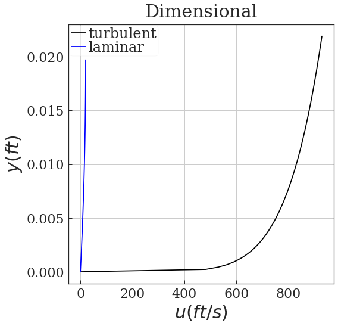

```python
delt_l = 5/np.sqrt(Re1)
delt_t = 0.16/Re2**(1/7)

y_t = delt_t*y_delt_t
u_t = v2*u_ue_t

y_l = delt_l*y_delt_l
u_l = v1*u_ue_l

plt.figure()
plt.plot(u_t,y_t,'k-',label='turbulent')
plt.plot(u_l,y_l,'b-',label='laminar')
plt.title('Dimensional')
plt.xlabel('$u (ft/s)$')
plt.ylabel('$y (ft)$')
plt.legend()
plt.show
```

Here we can see that the turbulent case has magnitudes more velocity than the laminar case everywhere inside the BL. This means that there will be more friction between the surface and the freestream because they are rubbing together more due to the massive increase in momentum.

Below the drag coefficient due to friction is calculated and used to calculate the drag forces for both cases.

```python
Cf_l = 2* 1.328/np.sqrt(Re1)
Cf_t = 2* 0.074/Re2**(1/5)
s = L * 15/12

Df_l = Cf_l*(0.5*rho1*v1**2 * s)
Df_t = Cf_t*(0.5*rho2*v2**2 * s)

print('The friction drag forces on the aircraft due to the fin is {:.4f} for the laminar BL'.format(Df_l))
print('The friction drag forces on the aircraft due to the fin is {:.4f} for the turbulent BL'.format(Df_t))
```

```
The friction drag forces on the aircraft due to the fin is 0.0032 for the laminar BL
The friction drag forces on the aircraft due to the fin is 2.1950 for the turbulent BL
```

Here we see that the drag for the laminar BL is pretty much negligible while not being so low for the turbulent BL. This is due to the fact that it is traveling much faster for the turbulent case. It is significant for the turbulent BL since it is such a small part of the plane, however, it seems manageable.

## Problem 2

### Method

For this problem, the provided code was utilized. There were some adjustments made to the ViscousCalcs, and VIvI functions in order to calculate the wall shear stress and drag coefficient due to friction.

### Equations

Displacement Thickness $\delta^*$: $$ H = \frac{\delta^*}{\theta} = 2.605 $$ Viscous contribution from friction: $$ C_f = \frac{1}{c}\int_0^c c_f dx; \qquad c_f = \frac{\tau}{\frac{1}{2}\rho_\infty V_\infty^2} $$ Wall Shear Stress $\tau$: $$ \tau = 0.332\frac{\mu u_e}{x}\sqrt{Re_x}$$ Momentum Thickness $\theta$: $$\theta = \frac{0.664x}{\sqrt{Re_x}} $$

### Code and Results

The first function obtain the velocity from Cp. The next one then obtains the momentum thickness at a specific point.

```python
#BERNOULLI'S RELATION
def Cp2V(Cp, Vinf):
    """Return velocity magnitude computed from pressure coefficient using
    Bernoulli's principle
    """
    return np.sqrt(1 - Cp) * Vinf
```

```python
#MOMENTUM THICKNESS FROM BLAUSIUS FLAT PLATE/VON KARMAN INTEGRAL RELATION
def MomThickness(x, u, Vinf, mu=1.79E-5, rho=1.225):
    """Compute momentum thickness at a given x-location along chord from
    equation derived by applying Blausius solution for flat plat to
    von Karmen integral relation for boundary layer.
    x --> coordinates along chord
    u --> surface velocity distribution as f(x) (from pot. flow soln)
    """
    #Compute momentum thickness at each X location (via von Karman relation)
    n = len(x) #number of x-locations
    c = max(x) - min(x)
    mom_thk = np.zeros(n) #initialize momentum thickness vector
    #Loop through each x-location
    for i in range(n):
        #integral portion is of surface velocity from LE up to current X
        integral = np.trapz(u[0:i] ** 8.210, x[0:i] * c)
        #momentum thickness from von karman
        mom_thk[i] = np.sqrt( (0.440 * mu) / (rho * u[i] ** 9.210) * integral )
    return mom_thk
```

The FixTE functions makes the trailing edge solvable in a potential flow.

```python
def FixTE(x, z, tol=1):
    """The displacement thickness due to the boundary layer at the
    trailing edge is so large that the TE becomes too blunt to solve correctly
    in a potential flow solver.  This function modifies an airfoil geometry
    so that the trailing edge is marginally sharper.
    x,z --> coordinates for ONE side of an airfoil (upper OR lower)
    tol --> surface slope tolerance (currently not used)
    """
    c = max(x) - min(x) #chord length

    #USE DATAFRAME FOR CONVENIENCE
    df = pd.DataFrame({'x' : x, 'z' : z})

    #FIND INDEX OF 90% CHORD LENGTH
    ind = df.loc[df.x >= c*0.9].index[0]

    #MAKE SURFACE FROM IND TO TE A STRAIGHT LINE (WEDGE)
    #number of points back to calc slope
    back = 5
    #Slope of airfoil surface at ind
    m = (df.loc[ind, 'z'] - df.loc[ind-back, 'z']) / (
         df.loc[ind, 'x'] - df.loc[ind-back, 'x'])
    #Fill rear surface points with straight line
    df.loc[ind:, 'z'] = (df.loc[ind:, 'x'] - df.loc[ind, 'x']) * m + df.loc[ind, 'z']

    return np.array(df['z'])
```

The ViscousCalcs function finds information needed for the viscous part of VIvI through the panel method solution. It modifies the original geometry by obtaining and using the momentum thickness, displacement thickness, and velocity.

```python
def ViscousCalcs(df, Vinf, mu, rho):
    """For a SINGLE surface (upper or lower):
    From an inviscid panel method solution,
    compute momentum thickness/displacement thickness from Blausius flat plate/
    von Karman integral relation.
    Add disp. thickness to original geometry to produce "displaced" geometry.
    Compute wall shear stress from momentum thickness.
    (Viscous portion of VIvI)
    df --> dataframe containing parameters for SINGLE surface
    """
    #COMPUTE DISPLACEMENT THICKNESS
    #Compute surface velocity from surface pressure distribution
    df['U'] = Cp2V(df.Cp, Vinf)
    #Compute momentum thickness from Blausius/von Karman
    df['theta'] = MomThickness(df.x, df.U, Vinf, mu, rho)
    #Compute displacement thickness
    H = 2.605 #Shape Parameter for Blausius distribution
    df['delta_star'] = H * df.theta

    #ADD DISP. THICKNESS TO GEOMETRY (POTENTIAL FLOW DIV. STREAMLINE)
    #add or subtract delta* depending on surface side
    surfactor = -1 if max(abs(df.z)) > max(df.z) else 1
    #add disp. thickness to airfoil
    df['zdisp'] = df['z'] + df['delta_star'] * surfactor
    #Sharpen TE for better panel solution
    df['zdisp'] = FixTE(np.array(df['x']), np.array(df['zdisp']))
    df['tau'] = 0.213808*mu*df['U']/df['theta']
    df['cf'] = df['tau']/(0.5*rho*Vinf**2)

    return df
```

Lastly, the VIvI function is called to perform a single iteration of the viscous/inviscid interaction. It runs an inviscid XFOIL simulation with the given geometry. It then uses the results to compute the displacement thickness along the geometry, and adds this to the given geometry in order to create the resulting surface.

```python
def VIvI(foilfile, alfa, niter=0, Vinf=1, mu=1.79E-5, rho=1.225):
    """SINGLE ITERATION of Viscous/Inviscid Interaction:
    Run invicid panel method simulation with provided geometry,
    compute displacement thickness of BL from surface pressure distribution,
    return "displaced" geometry, which can be used for another VIvI iteration
    foilfile --> path to airfoil geometry file
    alfa --> Single AoA at which to perform VIvI
    niter --> number for current iteration of VIvI
    Vinf, mu, rho --> freestream conditions
    """

    #GET INVISCID PANEL METHOD SURFACE PRESSURE SOLUTION

    #name and settings for specific iterations
    if niter == 0:
        #0th iteration
        num = ''
        pane = False
    else:
        #non-0th iteration
        num = '_{}'.format(niter)
        pane = True
    #name of current solution depends on VIvI iteration number
    geomfile = 'Data/{}/{}{}.dat'.format(foilfile, foilfile, num)
    #Run inviscid panel method
    invis = pyxfoil.GetPolar(geomfile, False, [alfa], Re=0, SaveCP=True, pane=pane, quiet=True)
    #Read panel method pressure distribution
    pressfile = 'Data/{}{}/{}{}_surfCP_Re0.00e+00a{:1.1f}.dat'.format(foilfile, num, foilfile, num, alfa)

    xCp = pyxfoil.ReadXfoilSurfPress(pressfile)
    #check of XFOIL solution failed
    if xCp.isnull().values.any():
        sys.exit('XFOIL solution failed for VIvI iteration: {}'.format(niter))

    #SPLIT MSES DATA INTO UPPER/LOWER SURFACES
    #Read current airfoil coordinates
    dfmses = pyxfoil.ReadXfoilAirfoilGeom(geomfile)
    #Compute chord length
    c = max(dfmses.x) - min(dfmses.x)
    #interpolate sufaces to this x
    xnew = np.linspace(0, c, 495)
    #store info for each surface in dictionary
    dfs = {'up' : pd.DataFrame(), 'lo' : pd.DataFrame()}
    #both sides have same x
    dfs['up']['x'], dfs['lo']['x'] = xnew, xnew
    #split surfaces
    dfs['up']['z'], dfs['lo']['z'] = mses.MsesInterp(xnew, dfmses.x, dfmses.z)
    #split surface pressure
    dfs['up']['Cp'], dfs['lo']['Cp'] = mses.MsesInterp(xnew, xCp.x, xCp.Cp)
    #save original geometry for plotting later
    dfog = dfs.copy()

    #VIVI COMPUTATIONS FOR EACH SURFACE
    for side in ['up', 'lo']:
        #compute displacement thickness from pressure distribution, add to geom
        dfs[side] = ViscousCalcs(dfs[side], Vinf, mu, rho)

    #MERGE AND SAVE DISPLACED GEOMETRY
    #Put displaced geometry into MSES format
    dfdisp = pd.DataFrame()
    dfdisp['x'], dfdisp['z'] = mses.MsesMerge(dfs['lo']['x'], dfs['up']['x'], dfs['lo']['zdisp'], dfs['up']['zdisp'])

    #Save displaced geometry in XFOIL format
    geomfile = 'Data/{}/{}_{}.dat'.format(foilfile, foilfile, niter+1)
    pyxfoil.WriteXfoilFile(geomfile, dfdisp.x, dfdisp.z)

    #RETURN UPPER/LOWER SURFACE MOMENTUM THICKNESS AND SURFACE VELOCITY DISTS.
    return dfs['up']['theta'], dfs['up']['U'], dfs['up']['tau'], dfs['up']['cf'], dfs['lo']['theta'], dfs['lo']['U'], dfs['lo']['tau'], dfs['up']['cf']
```

Below, the given example was modified in order to run VIvI for 3 iterations after the 0th iteration. The camber line was then calculated and plotted for each iteration.

```
Text(0.5,1,'Camber Lines of $0^{th}$, $1^{st}$, $2^{nd}$, & $3^{rd}$  Iters')
```

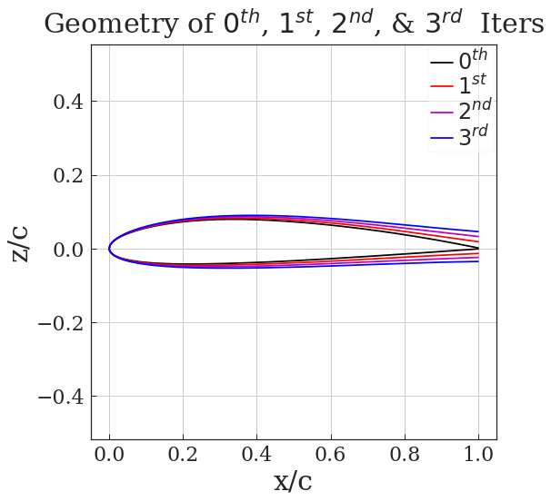

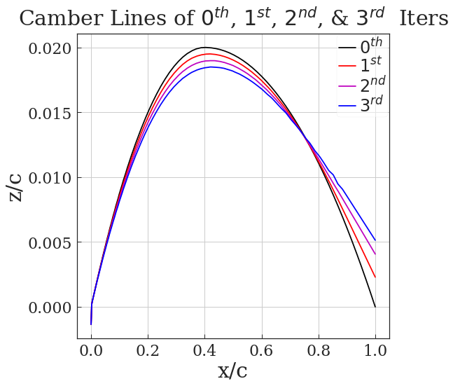

```python
#SETUP SIMULATION PARAMETERS
#airfoil name
    #(expects the geometry file 'Data/naca2412/naca2412.dat' to exist)
foil = 'naca2412'
#angle of attack to run VIvI at
alpha = 0
#Select start iteration (0th iteration for this case)
    #(chooses correct directory, e.g. 'Data/naca2412' for 0, 'Data/naca2412_1' for 1)
#Freestream Conditions
Vinf=1
mu=1.79E-5
rho=1.225
#RUN VIVI

plt.figure(1)
plt.figure(2)
colors = ['k','r','m','b']
iters = ['$0^{th}$', '$1^{st}$', '$2^{nd}$', '$3^{rd}$']
x = np.linspace(0,1,495)

for i in range(0,4):
    currentiter = i
    theta_up, ue_up,tau_up, cf_up, theta_lo, ue_lo, tau_lo, cf_lo = VIvI(foil, alpha, currentiter, Vinf, mu, rho)

    if i == 0:
        path = 'Data/naca2412/naca2412.dat'
    else:
        path = 'Data/naca2412/naca2412_{}.dat'.format(i)

    dfdisp = pyxfoil.ReadXfoilAirfoilGeom(path)
    xu, xl = mses.MsesInterp(x, dfdisp.x, dfdisp.x)
    zu, zl = mses.MsesInterp(x, dfdisp.x, dfdisp.z)
    plt.figure(1)
    plt.plot(xl, zl, linestyle = '-', color=colors[i], label= None)
    plt.plot(xu, zu, linestyle = '-', color=colors[i], label='{}'.format
    (iters[i]))
    plt.figure(2)
    plt.plot(xu, (zu+zl)/2, color=colors[i], label='{}'.format(iters[i]) )

    if i == 3:
        x_up, x_lo = mses.MsesSplit(dfdisp.x, dfdisp.x)
        cf_up = cf_up[2:]
        cf_lo = cf_lo[2:]
        x_up = x_up[2:]
        x_lo = x_lo[2:]
        Cf_up = np.trapz(cf_up, x_up)
        Cf_lo = np.trapz(cf_lo, x_lo)
        Cf = Cf_up + Cf_lo

plt.figure(1)
plt.legend(loc = 'best')
plt.xlabel('x/c')
plt.ylabel('z/c')
plt.title('Geometry of $0^{th}$, $1^{st}$, $2^{nd}$, & $3^{rd}$  Iters')
plt.axis('equal')

plt.figure(2)
plt.legend(loc = 'best')
plt.xlabel('x/c')
plt.ylabel('z/c')
plt.title('Camber Lines of $0^{th}$, $1^{st}$, $2^{nd}$, & $3^{rd}$  Iters')
```

From the Geometry figure it can be seen that for each iteration, the surfaces go further away from the original geometry. The top surface reparates more than the lower surface for each iteration, and as the iteration gets higher, the surfaces seems to be converging towards something. With our method, however, you could not see this convergence very clearly with more iterations.

Furthermore, the second graphs shows the camber of each iteration. We can see that all the iterations start with the same camber as x/c is less than 1/4. However, looking at the peak of the camber, it can be seen that there is decambering occuring as each iteration goes on. It does not appear as if the peak of the camber is converging towards anything, however, the endpoint at x/c = 1 is. The camber for it has gone from 0 to about 0.005 in three steps with decreasing size. This leads me to believe that the camber is also going to converge eventually.

Below, the coefficients of lift and drag are obtained for the Original Geometry through Inviscid and Viscous XFOIL runs as well as the third iteration geometry inviscid XFOIL results.

```python
print('The coefficient of drag from skin friction is: {:1.4f}'.format(Cf))
polar0 = pyxfoil.ReadXfoilPolar('Data/naca2412/naca2412_polar_Re0.00e+00a0.00.dat')
polar3 = pyxfoil.ReadXfoilPolar('Data/naca2412_3/naca2412_3_polar_Re0.00e+00a0.00.dat')
print('\nThird Iteration Geometry Inviscid Polar')
print(polar3)
print('\nOriginal Geometry Inviscid Polar')
print(polar0)

foil = '2412'
naca = True
alfs = 0
c = 1
Re = rho*Vinf*c/mu

pyxfoil.GetPolar(foil, naca, alfs, Re, SaveCP=True, quiet=True)
polar0Visc = pyxfoil.ReadXfoilPolar('Data/naca2412/naca2412_polar_Re6.84e+04a0.00.dat')
print('\nOriginal Geometry Viscous Polar')
print(polar0Visc)

print('\nThe Re is:', Re)
```

```
The coefficient of drag from skin friction is: 0.0130

Third Iteration Geometry Inviscid Polar
   alpha      Cl   Cd      Cdp      Cm  Top_Xtr  Bot_Xtr
0    0.0  0.1542  0.0 -0.00731 -0.0385      0.0      0.0

Original Geometry Inviscid Polar
   alpha      Cl   Cd      Cdp      Cm  Top_Xtr  Bot_Xtr
0    0.0  0.2555  0.0 -0.00106 -0.0558      0.0      0.0

Original Geometry Viscous Polar
   alpha      Cl       Cd      Cdp      Cm  Top_Xtr  Bot_Xtr
0    0.0  0.1108  0.02225  0.01388 -0.0443   0.9299      1.0

The Re is: 68435.75418994413
```

[output not shown]

The reynolds number for the problem was 6.84e4. This is well under the critical reynolds number which means that it is laminar flow.

The VIvI results for the $C_l$ is in between the values that XFOIL gets for inviscid and viscous flow for the original geometry. The VIvI $C_l$ is most comparable to the viscous XFOIL, but it is not exactly the same. For the $C_d$, the case is the same but differently. The $C_l$ for the VIvI is higher than the Viscous XFOIl and lower than the Inviscid XFOIL. This is then backwards for the $C_d$. This is due to the fact of inviscid flow does not take into account drag. The difference between the VIvI and the Viscous XFOIL could be because the VIvI did not fully converge to a final solution. It could also be because the VIvI function is based entirely on inviscid flow and the Blassius solutions of a flat plate. For the $C_d$, however, it is so different because our VIvI method only takes into account skin friction drag, and the Viscous XFOIL takes more than that into account. The error is then exacerbated by the fact that the panel method used is flawed, as well as the fact that XFOIL has a much higher fidelity method.

The limitations of the VIvI tool come from the fact that it is based on inviscid flow and the blassius solutions only. For this project, the trailing edge bluntness is also a problem. The inviscid panel method used cannot take into account drag forces. It is also flawed since the number of panels is limited and the boundary conditions are only applied at the center of each panel. The fact that one of the panels has to be removed to satisfy the kutta-condition only makes this problem worse. This all adds up to the tool breaking down after a few iterations before the results fully converge.

This method would then only be appropiate for thinner airfoils are low angles of attack. This is mainly due to the flat plate Blassius solution. In turn, this method would be innaproppiate for high angles of attack due to separation issues from the APG as well as for high Reynold's Numbers where the Blassius solutions become invalid.

A CFD solver that solves the RANS time averaged equation would be a better higher fidelity method. While not perfect, a CFD solver would be able to simulate the flow much better than our VIvI function.

### Conclusion

From this project, we can see how the viscous effects can be added to our previous vortex panel method. In order to do this, a Viscous/Inviscid Interaction tool (VIvI) is used. It can be seen in the results above that the Boundary Layer makes the airfoil thicker and decambered as more iterations are ran. The drag coefficient has to be computed separately from the momentum thickness and drag due to friction equations. This drag coefficient is significantly lower than Viscous XFOIL due to the fact that it is only skin friction drag. The implementation of the VIvI tool makes too many assumptions to be realistic and to have an useful range of iterations, however, it provides a simple understanding of viscous effects.